# Search

## Illustration of svd in image compression

See the demo of [Tim Baumann](https://timbaumann.info/svd-image-compression-demo/)

Example borrowed from [rich-d-wilkinson.github.io](https://rich-d-wilkinson.github.io/MATH3030/3-5-lowrank.html#eq:svdreduced)

The 512 × 512 colour image is stored as three matrices R, B, G of the same dimension 512×512 giving the intensity of red, green, and blue for each pixel. Naively storing this matrix requires 5.7Mb.

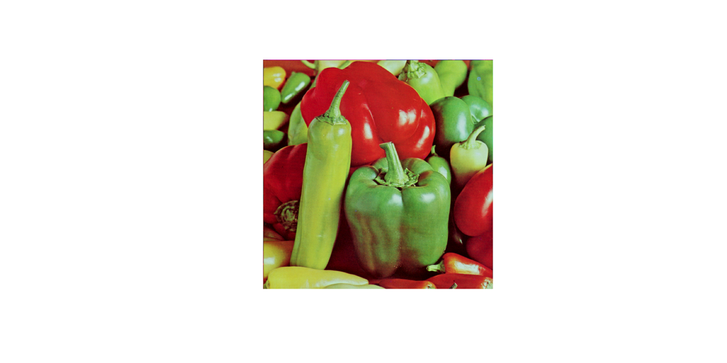

```r
library(tiff)
library(rasterImage)
peppers<-readTIFF("../Silo-Images/Peppers.tiff")
plot(as.raster(peppers))
```

## Illustration of svd in image compression

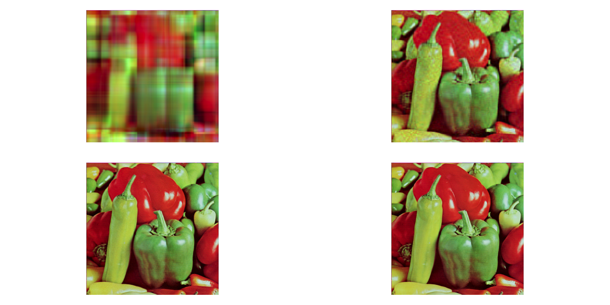

```r
svd_image <- function(im,k){
  s <- svd(im)
  Sigma_k <- diag(s$d[1:k])
  U_k <- s$u[,1:k]
  V_k <- s$v[,1:k]
  im_k <- U_k %*% Sigma_k %*% t(V_k)
   ## the reduced rank SVD produces some intensities <0 and >1.
  # Let's truncate these
  im_k[im_k>1]=1
  im_k[im_k<0]=0
  return(im_k)
}

par(mfrow=c(2,2), mar=c(1,1,1,1))

pepprssvd<- peppers
for(k in c(4,30,100,300)){
  svds<-list()
  for(ii in 1:3) {
    pepprssvd[,,ii]<-svd_image(peppers[,,ii],k)
  }
  plot(as.raster(pepprssvd))
}
```

## Low rank approximation of a matrix $\boldsymbol X$

### Frobenius norm

The Frobenius norm of a matrix $\boldsymbol X$ is defined as

$$\| \boldsymbol X\|^2_F = \sum_{ij} X_{ij}^2 = trace(\boldsymbol X^T \boldsymbol X) = \sum_{j=1}^r \sigma_j^2$$

### Rank k matrix $\hat{\boldsymbol X}_k$

Let

$$\hat{\boldsymbol X}_k = \sum_{j=1}^k \sigma_j \boldsymbol u_j \boldsymbol v_j^T$$

## Low rank approximation of a matrix

For any matrix $\boldsymbol X \in \mathbb R^{n\times d}$ with non null singular values $\sigma_1 \geq \sigma_2 \geq\ \cdots \geq \sigma_r$

$$\hat{\boldsymbol X}_k=\arg\min_{\hat{X} :rank(\hat{X})=k} \| {\boldsymbol X}- \hat{\boldsymbol X} \|^2_F$$

$$\min_{\hat{X} :rank(\hat{X})=k} \| {\boldsymbol X}- \hat{\boldsymbol X} \|^2_F = \sum_{j=k+1}^r \sigma_j^2$$

## Proof

We have

$$\|X-X_{k}\|_{F}^{2}=\left\|\sum _{i=k+1}^{n}\sigma _{i} u_{i}v_{i}^{\top }\right\|_{F}^{2}=\sum _{i=k+1}^{n}\sigma _{i}^{2}$$
We need to show that if $Y_{k}=AB^{\top }$ where $A$ and $B$ have k columns then

$$\|X-X_{k}\|_{F}^{2}=\sum _{i=k+1}^{n}\sigma _{i}^{2}\leq \|X-Y_{k}\|_{F}^{2}.$$

## Proof

By the triangle inequality with the spectral norm, if $X=X'+X''$ then $\sigma _{1}(X) \leq \sigma_{1}(X')+\sigma _{1}(X'')$ .

Suppose $X'_{k}$ and $X''_{k}$ respectively denote the rank k approximation to $X'$ and $X''$ by SVD.

Then, for any $i,j \geq 1$

$$\begin{aligned}\sigma _{i}(X')+\sigma _{j}(X'')&=\sigma _{1}(X'-X'_{i-1})+\sigma _{1}(X''-X''_{j-1})\\
&\geq \sigma _{1}(X-X'_{i-1}-X''_{j-1})\\
&\geq \sigma _{1}(X-X_{i+j-2})\qquad ({\text{since }}{\text{rank}}(X'_{i-1}+X''_{j-1})\leq {\text {rank\,}}(X_{i+j-2}))\\&=\sigma _{i+j-1}(X).
\end{aligned}$$

## Proof

Since $\sigma _{k+1}(Y_{k})=0$, when $X'=X-Y_{k}$ and $X''=Y_{k}$ we conclude that for $i\geq 1,j=k+1$

$\sigma _{i}(X-Y_{k})+\underbrace{\sigma _{k+1}(Y_{k})}_{0} \geq \sigma _{k+i}(X).$ Therefore,

$$\|X-Y_{k}\|_{F}^{2}=\sum _{i=1}^{n}\sigma _{i}(X-Y_{k})^{2}\geq \sum _{i=k+1}^{n}\sigma _{i}(X)^{2}=\|X-X_{k}\|_{F}^{2}.$$

## Low rank approximation of a matrix and projection

If $rank(\hat{X})=k$, then we can assume columns $\hat{X}_i$ of $\hat{\boldsymbol X} \in E_k=span\{\boldsymbol w_1, \boldsymbol w_2,\cdots , \boldsymbol w_k\}$ where $\{\boldsymbol w_1, \boldsymbol w_2,\cdots , \boldsymbol w_k\}$ is a set of orthonormal vectors for the linear space of columns of $X_k$. First, observe that

$$\| \boldsymbol X-\hat{\boldsymbol X} \|^2_F = \sum_i \|X_i - \hat{X}_i\|^2$$

### Optimum solution is the orthogonal projection

For each term $\| X_i-v \|_2^2$,the optimum solution is the projection of $X_i$ onto $E_k=span \{\boldsymbol w_1, \boldsymbol w_2,\cdots , \boldsymbol w_k \}$:

$$\hat{X}_i = \sum_{j=1}^k \langle X_i,\boldsymbol w_j \rangle \boldsymbol w_j = \Pi_{E_k} X_i.$$

where $\Pi_{E_k}=\sum_{j=1}^k \boldsymbol w_j\boldsymbol w_j^T$

## Projection on the orthogonal subspace

Consider $\Pi_{E^\perp_k}$ the projection matrix on the space orthogonal to $E_k$. More precisely, let us add $\boldsymbol w_{k+1},\cdots,\boldsymbol w_n$ such that $\boldsymbol w_{1},\cdots,\boldsymbol w_n$ form an orthonormal basis of $\mathbb R^n$. Then,

$$\Pi_{E^\perp_k}=\sum_{j=k+1}^n \boldsymbol w_j\boldsymbol w_j^T$$

$$\| X-\hat X \|^2_F = \| X-\Pi_{E_k} X \|^2_F = \| (I-\Pi_{E_k}) X \|^2_F = \|\Pi_{E^\perp_k} X \|^2_F$$

## Relation to principal component analysis

### Warning

**$\boldsymbol X$ is considered as centered**. This tranformation (cloud translation allows considerable simplification)

### Decomposition of $X$

Considering the orthonal projection on $E_k$
$$\boldsymbol X= \Pi_{E_k} \boldsymbol X + \Pi_{E^\perp_k} \boldsymbol X$$

## Criterion

$$\| \boldsymbol X\|^2_F= \underbrace{\|\Pi_{E_k} \boldsymbol X\|^2_F}_{approximation} + \underbrace{\|\Pi_{E^\perp_k} \boldsymbol X\|^2_F}_{error}$$

In terms of intertia, PCA maximizes the projected inertia (approximation) while minimizing the ditances to the space of projection (error):
$$I_T = I_E+ I_{E^\perp_k}$$

## Best low rank approximation

$$\hat{\boldsymbol X}_k=\Pi_{E_k} \boldsymbol X = \sum_{j=1}^k \sigma_j \boldsymbol u_j \boldsymbol v_j^T = \boldsymbol U_{\bullet,1:k} \boldsymbol S_{1:k,1:k} \boldsymbol V_{\bullet,1:k}^T$$
where $\boldsymbol X=\underbrace{\boldsymbol U}_{n\times n}\ \underbrace{\boldsymbol S}_{n\times d}\underbrace{\boldsymbol V}_{d\times d}^T$

## Different views of the approximation

The approximation
$$\| \boldsymbol X - \hat{\boldsymbol X} \|^2_F$$
can be considered in multiple ways:

- approximation of the row
- approximation of the columns

### Notations

If $\boldsymbol X$ is a data table,

- each row $\boldsymbol x_i^T$ is a description of an individual
- each colum $X_j$ is variable describing $n$ individuals

## Rows approximation (projection of the individuals)

Transposing the matrix the best low rank approximation becomes

$$\hat{\boldsymbol X^T}_k=\Pi_{F_k} \boldsymbol X^T = \sum_{j=1}^k \sigma_j \boldsymbol v_j \boldsymbol u_j^T = \boldsymbol V_{\bullet,1:k} \boldsymbol S_{1:k,1:k} \boldsymbol U_{\bullet,1:k}^T$$
where $F_k=span\{\boldsymbol v_1,\cdots, \boldsymbol v_k\}$

## The approximation error

$$\begin{aligned}
\|\boldsymbol X - \hat{\boldsymbol X}\|^2_F = \|\boldsymbol X^T - \hat{\boldsymbol X^T}\|^2_F & =& \sum_i \|\boldsymbol x_i - \hat{\boldsymbol x}_i\|^2_2
\end{aligned}$$
Each row $\boldsymbol x_i$ is approximated by

$$\hat{\boldsymbol x_i} = \Pi_{F_k} \boldsymbol x_i = V_{F_k} V_{F_k}^T \boldsymbol x_i$$
where $\boldsymbol V_{F_k}$ is the matrix composed of the vectors defining $F_k$.

## Projection of the variables

$\Pi_{E_k}$ is the projection matrix on $E=span(\boldsymbol u_1, \cdots, \boldsymbol u_k)$

$$\Pi_E = \boldsymbol U_{E_k} \boldsymbol U_{E_k}^T$$
and
$$\Pi_{E_k} \boldsymbol X =
\boldsymbol U_{1:n,1:k} \underbrace{\boldsymbol U_{1:n,1:k}^T \boldsymbol U_{1:n,1:n}}_{(I_k, 0_{k,n-k})} \boldsymbol S_{1:n,1:k}\boldsymbol V_{1:d,1:d}^T = \boldsymbol U_{1:n,1:k} \boldsymbol S_{1:k,1:k} \boldsymbol V_{1:d,1:k}^T$$

## k first principal components

$$\boldsymbol C_{1:n,1:k} = \boldsymbol U_{E_k} \boldsymbol S_{1:k,1:k}$$
where $\boldsymbol S_{1:k,1:k} = diag(\sigma_1,\cdots, \sigma_k)$.

The principal component are the coordinates of the projection of the rows of $\boldsymbol X$ on $F_k$:

$$\boldsymbol C_{1:n,1:k} = \boldsymbol X \boldsymbol V_{1:d,1:k}$$

## Percentage of information

We have $\boldsymbol C_{\bullet,1:k}^T \boldsymbol C_{\bullet,1:k} = S_{1:k,1:k}^2 = diag(\sigma_1^2,\cdots,\sigma_k^2)$, thus
$$\|\boldsymbol C_{\bullet,1:k}\|^2_F = \sum_{j=1}^k \sigma_j^2$$

and

$$\frac{\| \boldsymbol C_{\bullet,1:k} \|^2_F}{\| \boldsymbol X \|^2_F}=\frac{\sum_{j=1}^k \sigma_j^2}{\sum_{j=1}^d \sigma_j^2}\in [0,1]$$

## Correlations

$$\widehat{cor}(\boldsymbol X_{\bullet,j},\boldsymbol C_{\bullet,k}) = \frac{X_{\bullet,j}^T\boldsymbol C_{\bullet,k}}{\|X_{\bullet,j}\| \|\boldsymbol C_{\bullet,k}\|}= \cos\widehat{(\boldsymbol X_{\bullet,j},\boldsymbol C_{\bullet,k})}$$

## Duality

It is easy to show that

- the columns of $\boldsymbol V$ are the eigenvector of $\boldsymbol X^T \boldsymbol X$
- the columns of $\boldsymbol U$ are the eigenvector of $\boldsymbol X \boldsymbol X^T$

Thus the principal component of $\boldsymbol X^T \boldsymbol X$ are the eigenvectors of $\boldsymbol X \boldsymbol X^T$ and vice-versa

# Multi Dimensional Scaling

## Dimensionality reduction and manifold learning

### Goal

Given pairwise

- dissimilarities $\delta_{ij}$ or
- high-dimensional input data $\{\boldsymbol x_i\}_{i=1\cdots...n}$

reconstruct a lower dimensional map with embedded data $\{\boldsymbol y_i\}_{i=1\cdots...n}$

### Principle

- Minimize an objective function quantiying the discrepancies between the $\delta_{ij}$ and the distances $d(\boldsymbol y_i, \boldsymbol y_j)$
- w.r.t $\{\boldsymbol y_i\}_{i=1\cdots...n}$.

## A Brief history

The methodology of Multidimensional Positioning (Multidimensional Scaling, MDS) was born in the USA in the 1950s

- Works of Torgerson (1952, 1958),
- Works of Shepard (1962),

initial applications to sparse data in

- psychometrics,
- marketing,
- sensory analysis.

## Proximity measures

### Distance

The function $d$ from $E \times E$ in $\mathbb{R}^{+}$ is a distance if it satisfies the following properties:

- $\forall i,j \in E, \ d_{ij}=d_{ji}$
- $\forall i \in E, \ d_{ii}=0$
- $\forall i,j \ and \ k \in E, \ d_{ik}\leq d_{ij} + d_{jk}$

### Dissimilarity

The function $\delta$ of $E \times E$ in $\mathbb{r}^{+}$ is a distance if it satisfies the following properties:

- $\forall i,j \in E, \ \delta_{ij}=\delta_{ji}$
- $\forall i \in E, \ \delta_{ii}=0$

## Classical scaling

Also known as Torgerson scaling, principal coordinate analysis (PCoA), …

### Principle

- assume that the dissimilarities are distances and
- find the main coordinates that explain the distances.

## From distances to scalar product

- How to calculate the distance matrix from $X$?
  $$\begin{eqnarray*}
  d_{ij}^2 &=& \sum_{a=1}^p (x_{ia}^2 + x_{ja}^2 -2 x_{ia}x_{ja} )\\
  &=& \sum_{a=1}^p x_{ia}^2 + \sum_{a=1}^p x_{ja}^2 - 2
  \sum_{a=1}^p x_{ia}x_{ja}
  \end{eqnarray*}$$
  from where

$$D^{2} = diag(XX^t) \mathbb{I}_{(1,n)} + \mathbb{I}_{(n,1)} diag(XX^t)^t -
2XX^t$$
## Distance and data table (continued)}

- Let $J$ be the centering matrix,
  $$J = I - \frac{1}{n} \mathbb{I}_{(n,n)}$$
- Centering of $X$ in columns
  $$JX = X - \frac{1}{n} \mathbb{I}_{(n,n)} X$$
- Centering of $X$ in rows
  $$X^t J = X^t - \frac{1}{n} X^t \mathbb{I}_{(n,n)} X$$

## Distance and data table (continued)}

### Problem: we know $D^2$, we want $X$: Double centering

$$\begin{eqnarray*}
-\frac{1}{2} J D^2 J &=& -\frac{1}{2} J diag(XX^t)* \mathbb{I}_{(1,n)} J\\
& & -\frac{1}{2} J \mathbb{I}_{(n,1)} diag(XX^t)^t J \\
& & + J XX^t J \\
&=& X X^t
\end{eqnarray*}$$

## Low rank approximation and principal coordinates

The idea is to minimize
$$\| XX^T - Y Y^T\|_F^2$$
w.r.t $rank(YY^T)=k$

We know the minimum is a low rank apprixation $B=YY^T$ of rank $k$

$$B = (U_{E_k} S_{1:k,1:k})(S_{1:k,1:k}^T U_{E_k}^T) = Y Y^T$$

- the analysis of the triple consists in replacing the matrix $D^2$ by the matrix of the square of dissimilarities $\Delta^2$

### Remark

If $\Delta^2$ is a distance matrix the solution $Y= U_{E_k} S_{1:k,1:d}$ (first k principal components of $X^TX$) is optimal and PCoA is equivalent to PCA.

## Algorithm

1. Compute the matrix $\Delta^2$
2. Double centering of $\Delta^2$:
   $$B_{\Delta^2}= -\frac{1}{2} J \Delta^2 J$$
3. Spectral decomposition of $B_{\Delta^2}$~:
   $$B_{\Delta^2} = U \Lambda U^t$$
4. Let $k$ be the representation dimension chosen for the solution.
- $\Lambda_{+}$ is the matrix of $k$ largest eigenvalues, listed in descending order on the diagonal.
- $U^{+}$ is the matrix of $k$ corresponding eigenvectors
- **The solution of the problem** is
  $$Y= U^{+} \Lambda_{+}^{\frac{1}{2}}$$

## Optimized criterion

- the optimized criterion is
  $$\begin{eqnarray*}
  L(X) &=& || -\frac{1}{2} J(D^2(X) - \Delta^2)J ||^2 \\
  & =& || XX^t + \frac{1}{2} J \Delta^2)J ||^2\\
  &=& || X X^t - B_{\Delta^2}||^2
  \end{eqnarray*}$$
  with $B_{\Delta^2}$ of rank $k$
- Remarks: If $\Delta$ is a dissimilarity matrix then some principal components will be negative!

## Models and functions for the MDS

MDS matches proximities $\delta_{ij}$ to distances $d_{ij}$ between objects:
$$f: \delta_{ij} \longrightarrow d_{ij}(Y)$$
with $Y$ a classical array of low dimensional data - the dissimilarities $\delta_{ij}$ are the data of the pb - the distances $d_{ij}(Y)$ are the unknowns

- the MDS finds a configuration $Y$ in a space of dimension $m$, used to calculate distances $d_{ij}$

## In practice

the dissimilarities are marred by errors and one does not look for $f$ such that
$$f(\delta_{ij}) = d_{ij}(Y)$$
but rather
$$f(\delta_{ij}) \approx d_{ij}(Y)$$

## Error function

### Definition of an error function

$$e_{ij}= \large( f(\delta_{ij}) - d_{ij}(Y) \large)^2$$

### Raw global error (raw stress)

$$\sigma_{r}^2(Y) = \sum_{i>j} \large( f(\delta_{ij}) - d_{ij}(Y) \large)^2$$

- The global error is not very informative~: A large value of $\sigma_{r}^2(Y)$ does not necessarily indicate bad result.

## Normalized error function

### Normalized Stress

$$\sigma_{n}^2(Y) = \frac{\sum_{i>j} \Big( f(\delta_{ij}) -
d_{ij}(Y) \Big)^2}
{\sum_{i>j} d_{ij}^2(Y)}$$

### A general form

$$\sigma^2(Y) = \sum_{i>j} w_{ij} \Big( f(\delta_{ij}) - d_{ij}(Y) \Big)^2$$

## Different approaches

- metric: quantitative approach
- non-metric : qualitative approach

### Metric approach

Algebraic transformation of $\delta_{ij}$ (e.g. $f(\delta_{ij})=a \delta_{ij} + b$)

With
$$f(\delta_{ij})=\delta_{ij} + b(1 -\mathbb{I}_{(i=j)})$$
assurance of the existence of an $Y$ configuration of dimension $n-2$ at most such that

$$f(\delta_{ij})=d_{ij}(Y)$$

### Non-metric approach

- $f$ is a monotone function that preserves order relations
- if $\delta_{ij}<\delta_{kl}$ then $f(\delta_{ij}<f(\delta_{kl}))$

## Sammon’s Projection

Metric Method: “Projection” into a space of low dimension (1,2, or 3)

- $Y= (\mathbf{y}_{1},\ldots,\mathbf{y}_{n})^t$ configuration sought
- Euclidian distance

$$\begin{eqnarray}
d_{ij}& = & d(\mathbf{y}_{i},\mathbf{y}_{j}) \\
& = & \|\mathbf{y}_{i}-\mathbf{y}_{j}\|_2
\end{eqnarray}$$

## Sammon stress function

Sammon searches for the $\mathbf{y}_{i}$ minimizing

$$S(Y) = \frac{1}{\sum_{i<j} \delta_{ij}} \frac{\sum_{i<j}
(\delta_{ij} - d_{ij}(Y))^2}{\delta_{ij}}$$

- $f$ identity
- $w_{kl}=\frac{1}{(\sum_{i<j}\delta_{ij}) \delta_{kl}}$

### Remarks:

Sammon’s Stress

- is invariant to rotations, translation and scaling
- focuses on small distances

## Minimisation of Sammon’s Stress

- minimisation of a function from $\mathbb{R}^{n\times k}$ to $\mathbb{R}$
- Global minimum is difficult to reach
- Gradient descent

### Remarks

- Many possible optimmisation methods
- Initial Random configuration

## Example in R

### `sammon` from library MASS

```
  Sammon's Non-Linear Mapping

Description
 One form of non-metric multidimensional scaling.

Usage
 sammon(d, y = cmdscale(d, k), k = 2, niter = 100, trace = TRUE,
 magic = 0.2, tol = 1e-4)
```

## Sammon gradient

Let show that
$$\frac{\partial S(Y)}{\partial y_{ik} }= -2\sum_{j<i} w_{ij}\frac{\delta_{ij}-d_{ij}}{d_{ij}}(y_{ik} - y_{jk})$$
From chain rule

$$\frac{\partial S(Y)}{\partial y_{ik}} = \underbrace{\frac{\partial S(Y)}{\partial\|y_i- y_j\|} }_1 \times \underbrace{\frac{\partial\|y_i- y_j\|}{ \partial y_{ik}}}_2$$

1. $\frac{\partial S(Y)}{\partial d_{ij}}== -2\sum_{j<i} w_{ij} (\delta_{ij}-d_{ij})$
2. $\frac{\partial\|y_i- y_j\|}{ \partial y_{ik}} = \frac{\partial d_{ij}}{\partial d_{ij}^2}\frac{\partial d_{ij}^2 }{\partial y_{ik}}= \frac{y_{ik}-y_{jk}}{d_{ij}}$

## Sammon gradient descent

At iteration $q$
$$y^{(q+1)}_{ik} := y^{(q)}_{ik} - \eta \frac{\partial S(Y)}{\partial y_{ik}}$$

## Example Ekman colors

Ekman presents similarities for 14 colors which are based on a rating by 31 subjects where each pair of colors was rated on a 5-point scale (0 = no similarity up to 4 = identical). After averaging, the similarities were divided by 4 such that they are within the unit interval. Similarities of colors with wavelengths from 434 to 674 nm.

## Example Ekman colors

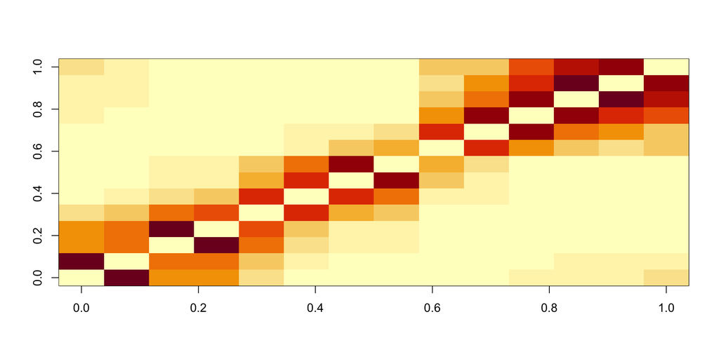

## Example Classical scaling

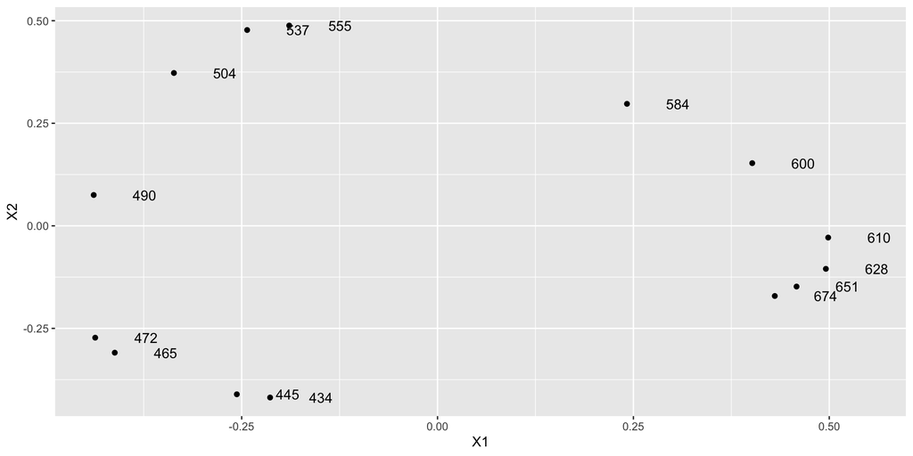

# t-SNE

Variation of Stochastic Neighbor Embedding

- easier to optimize,
- produces significantly better visualizations by reducing the tendency
- scalable: for very large data sets, t-SNE can use random walks on neighborhood graphs

## Stochastic Neighbor Embedding

Stochastic Neighbor Embedding (SNE) converts distances into conditional probabilities that represent similarities

### Conditional probabilities $p_{j|i}$

$$p_{j|i} = \frac{\exp(-\|x_i - x_j\|^2/(2\sigma_i^2))}{\sum_{k\neq i} \exp(-\|x_i
- x_k\|^2 / 2 \sigma_i^2)}\,.$$

### Interpretation

Probability that $x_i$ would pick $x_j$ as its neighbor if neighbors were picked in proportion to their probability density under a Gaussian centered at $x_i$:

## Stochastic Neighbor Embedding

similar conditional probability between the $y_i$, which we denote by $q_{j|i}$.

### Conditional probabilities, $q_{j|i}$

$$q_{j|i} = \frac{\exp(-\|y_i - y_j\|^2)}{\sum_{k \neq i} \exp(-\|y_i
-y_k\|^2)}\,.$$
with $q_{i|i}=0$.

### SNE can also be applied directly to similarity data

provided similarities can be interpreted as conditional probabilities we set

## Cost function

A natural measure of the faithfulness with which $q_{j|i}$ models $p_{j|i}$ is the Kullback-Leibler divergence (equal to the cross-entropy up to an additive constant).

$$C = \sum_i KL(P_i\|Q_i) = \sum_i \sum_j p_{j|i} \log
\frac{p_{j|i}}{q_{j|i}}\,,$$

the SNE cost function focuses on retaining the local structure of the data in the map (for *reasonable values of the variance* of the Gaussian in the high-dimensional space).

## Selecting the variance $\sigma_i$

SNE performs a binary search for the value of $\sigma_i$ that produces a $P_i$ with a fixed perplexity that is specified by the user

### Perplexity

$$Perp(P_i) = 2^{H(P_i)}\,,$$
where $H(P_i)$ is the Shannon entropy of $P_i$ measured in bits

$$H(P_i) = - \sum_j p_{j|i} \log_2 p_{j|i}\,.$$

### Remarks

- the perplexity increases monotonically with the variance $\sigma_i$
- smooth measure of the effective number of neighbors
- Typical values are between 5 and 50.

## Gradient descent

### Gradient

$$\frac{\partial C}{\partial y_i} = 2 \sum_j (p_{j|i} - q_{j|i} + p_{i|j} -
q_{i|j})(y_i - y_j)\,.$$

### Interpretation

The gradient may be interpreted as the resultant force created by a *set of springs* between the map point $y_i$ and all other map points $y_j$.

- force exerted by the spring between $y_i$ and $y_j$ is proportional to its length
- also proportional to its stiffness $(p_{j|i} - q_{j|i} + p_{i|j} + q_{i|j})$

### Initialisation

$n$ points randomly sampled from an isotropic Gaussian with small variance that is centered around the origin

## Gradient in practice

- To speed up the optimization and to avoid poor local minima, a relatively large momentum term is added to the gradient:

$$\mathcal{Y}^{(t)} = \mathcal{Y}^{(t-1)} + \eta \frac{\partial C}{\partial
\mathcal{Y}} + \alpha(t) \left( \mathcal{Y}^{(t-1)} - \mathcal{Y}^{(t-2)}\right)\,,$$

where $\mathcal{Y}^{(t)}$ indicates the solution at iteration $t$, $\eta$ indicates the learning rate, and $\alpha(t)$ represents the momentum at iteration $t$.

- In addition, in the early stages of the optimization, Gaussian noise is added to the map points after each iteration. Gradually reducing the variance of this noise performs a type of simulated annealing

## t-Distributed Stochastic Neighbor Embedding

### t-SNE vs SNE

1. Uses a symmetrized version of the SNE cost function with simpler gradients
2. Student-t distribution rather than a Gaussian to compute the similarity between two points *in the low dimensional space*.

## Symmetric SNE

$$C = KL(P\|Q) = \sum_i \sum_j p_{ij} \log \frac{p_{ij}}{q_{ij}}\,,$$

where $p_{ii}$ and $q_{ii}$ to zero.

- $p_{ij} = p_{ji}$ and
- $q_{ij} = q_{ji}$ for all $i, j$.

### Joint probabilies $p_{ij}$

$$p_{ij} = \frac{\exp(-\|x_i - x_j\|^2/2\sigma^2)}{\sum_{k\neq l} \exp(-\|x_k -
x_l\|^2/2\sigma^2)}\,$$

### Joint probabilies $q_{ij}$

$$q_{ij} = \frac{\exp(-\|x_i - x_j\|^2)}{\sum_{k\neq l} \exp(-\|x_k -
x_l\|^2)}\,.$$

## t-SNE

Problems when a high-dimensional datapoint $x_i$ is an outlier, the values of $p_{ij}$ are extremely small for all $j$, so the location of its low-dimensional map point $y_i$ has very little effect on the cost function.

- $p_{ij} = \frac{p_{j|i} + p_{i|j}}{2n}$. ensures that $\sum_j p_{ij} > \frac{1}{2n}$ $\forall x_i$,
- each $x_i$ makes a significant contribution to the cost function.

### t-SNE Gradient

The main advantage of the symmetric version of SNE is the simpler form of its gradient, which is faster to compute.
$$\frac{\partial C}{\partial y_i} = 4 \sum_j (p_{ij} - q_{ij})(y_i - y_j)\,.$$

symmetric SNE produces maps that are just as good as asymmetric SNE

## The Crowding Problem

> the area of the two-dimensional map that is available to accommodate moderately distant datapoints will not be nearly large enough compared with the area available to accommodate nearby datapoints.
- Modeling the small distances accurately has detrimental effect on moderate distances representation
- the crowding problem is not specific to SNE

## Mismatched tails can compensate for mismatched dimensionalities

### $t$-distribution for the $q_{ij}$

Student distribution with a single degree of freedom also known as a Cauchy distribution
$$q_{ij} = \frac{(1+\|y_i - y_j\|^2)^{-1}}{\sum_{k \neq l}(1+\|y_k -
y_t\|^2)^{-1}}$$

### Gradient

$$\frac{\partial C}{\partial y_i} = 4 \sum_j (p_{ij} - q_{ij})(y_i -
y_j)(1+\|y_i - y_j\|^2)^{-1}\,.
\tag{1}$$

## Two optimization tricks

### “Early compression”

- Force the map points to stay close together at the start of the optimization.
- Easy for clusters to move through one another and thus to explore the space of solutions
- implemented by adding an additional L2-penalty to the cost function that is proportional

### “Early exaggeration”

Multiply all of the $p_{ij}$’s by, for example, 4, in the initial stages of the optimization.

- natural clusters in the data tend to form tight widely separated clusters in the map.
- creates a lot of relatively empty space in the map
- makes it much easier for the clusters to move around relative to one another

## Uniform manifold approximation and projection (UMAP)

UMAP works directly with similarities and uses cross-entropy as a criterion.

### Distance in high dimensional space

$$v_{j|i} = \exp\left[(-d(x_i, xj ) - \rho_i)/\sigma_i\right]$$

- $d (x_i, x_j)$ is the distance between $x_i$ and $x_j)$, which UMAP does not require to be Euclidean.
- $\rho_i$ is the distance to the nearest neighbor of $i$.
- $\sigma_i$ is the normalizing factor, which is chosen by a specific Algorithm and plays a similar role to the perplexity-based calibration of $\sigma_i$ in t-SNE.

Symmetrization is carried out by fuzzy set union
$$v_{ij} =v_{j|i} + v_{i|j} - v_{j|i}v_{i|j}$$

## Uniform manifold approximation and projection (UMAP)

### Low dimensional similarities

$$w_{ij}= (1 + a \|y_i - y_j\|^{2b}_2)^{-1}$$
where $a$ and $b$ are user-defined positive values

### Cost function (cross-entropy)

$$C_{UMAP} =
\sum_{i\neq j} v_{ij} \log \frac{v_{ij}}{w_{ij}} + (1 - v_{ij} ) \log \frac{1 - v_{ij} }{1 - w_{ij}}$$

Optimization process is done by stochastic gradient descent

## UMAP vs t-SNE

In terms of performance,

- UMAP is often considered to produce more stable and consistent results than t-SNE,
- especially when dealing with large datasets.

On the other hand,

- t-SNE is often considered to produce more visually appealing results,
- especially when dealing with small datasets.

# Word Embedding

# Word embedding

## Words and Vectors

Vector or distributional models of meaning are generally based on a co-occurrence matrix

### Two common co-occurrence matrix

- the word-document matrix
- the word-word matrix.

## Word-document matrix

In a Word-document matrix, each row represents a word in the vocabulary and each column represents a document from some collection of documents.

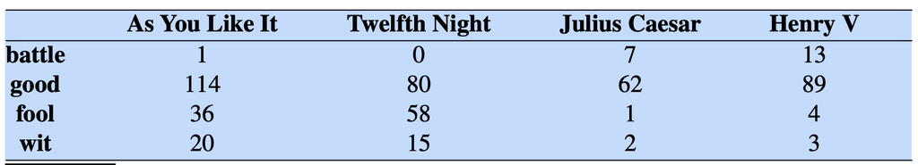

*Number of words occurence in 4 Shakespeare plays (from speech and langage processing)*

## Word-Word matrix

In the Word-context matrix the columns are labeled by words rather than documents.

- each cell records the number of times the row (target) word and the column (context) word co-occur in some context in some training corpus.

### Context

- a context could be the document, in which case the cell represents the number of times the two words appear in the same document.
- smaller contexts are common: generally a window around the word

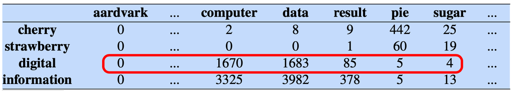

*word-word matrix from a Wikipedia corpus (from speech and langage processing)*

## Cosine for measuring similarity

The cosine similarity metric (or empirical correlation) between two word vectors $\boldsymbol v$ and $\boldsymbol w$ (lines of a word-document or word-word matrix)

$$\cos(\boldsymbol v,\boldsymbol w) = \frac{\boldsymbol v^T \boldsymbol w}{\|\boldsymbol v\| \|\boldsymbol w\|}$$

## TF-IDF: Weigthing terms in the vector

### Term frequency (tf)

- Raw frequency $tf_{t,d} = count(t,d)$ is very skewed and not very discriminative.
- Usually squashed by using the $log10$: a word appearing 100 times in a document doesn’t make that word 100 times more relevant
  $$\text{tf}_{t,d} = \log_{10}\left(count(t,d)+1\right)$$

### Inverse document frequency

The second factor in tf-idf is used to give a higher weight to words that occur only in a few documents.
$$idf_t = \log_{10}\left(\frac{N}{\text{df}_t}\right)$$
where $N$ is the total number of documents, and $df_t$ is the number of documents in which term $t$ occurs.

## TF-IDF: Weigthing terms in the vector

The tf-idf weighted value $w_{t,d}$ for word $t$ in document $d$ thus combines term frequency $tf_{t,d}$ with $idf$:
$$w_{t,d} = tf_{t,d} \times idf_t$$

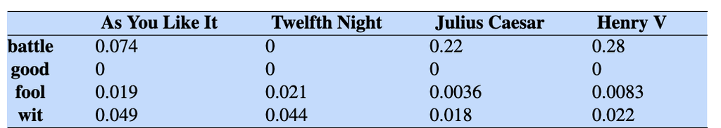

*A tf-idf weighted term-document matrix. Note that the tf-idf weighting has eliminated the importance of the ubiquitous word good and vastly reduced the impact of the almost-ubiquitous word fool.*

## Pointwise Mutual Information (PMI)

An alternative weighting function to tf-idf, PPMI (positive pointwise mutual information), is used for **term(target)-term(context)-matrices**.

- Target word, word we focus on.
- Context words surrounding the target word

The pointwise mutual information between a target word $w$ and a context word $c$ (Church and Hanks 1989, Church and Hanks 1990) is defined as:
$$PMI(w, c) = \log_2 \frac{P(w, c)}{ P(w)P(c)}$$

## Positive PMI (called PPMI)

Negative PMI values (which imply things are co-occurring less often than we would expect by chance) tend to be unreliable unless our corpora are enormous.

### Positive PMI

replaces all negative PMI values with zero (Church and Hanks 1989, Dagan et al. 1993, Niwa and Nitta 1994)

$$PPMI(w, c) = \max(\log_2 \frac{P(w, c)}{P(w)P(c)} , 0)$$

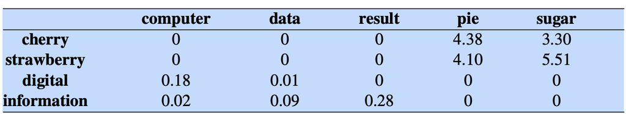

*A PPMI matrix showing the association between words and context words*

## Applications of the tf-idf or PPMI vector models

### Principle

- Computing two documents (or word) similarity after transformation.
- Given two documents $d_1$ and $d_2$, the similarity is $\cos(d_1,d_2)$.

### Applications

- **Documents** : information retrieval, plagiarism detection, news recommender systems, and even for digital humanities tasks like comparing different versions of a text to see which are similar to each other.
- **Words** : finding word paraphrases, tracking changes in word meaning, or automatically discovering meanings of words in different corpora.

## Latent Semantic Analysis (LSA)

### Goal and assumptions

- extracting and representing the underlying meaning of words in a corpus of texts.
- words that occur in similar contexts have similar meanings.

### Principle

LSA uses singular value decomposition (SVD) to identify latent, or hidden, patterns in word co-occurrence data.

## Latent Semantic Analysis

LSA uses SVD on the matrix of word-document matrix to identify the latent concepts (contexts, topics, …) that underlie the relationships between words in the corpus: $W = U S V^T$ with classical low rank approximation $U_k S_k V_k^T$

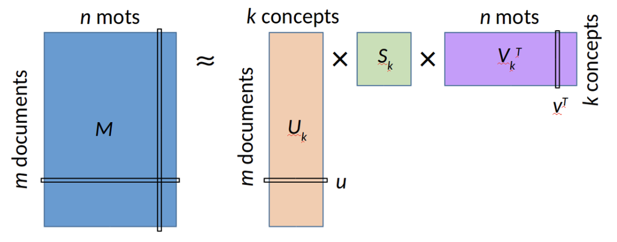

## Latent Semantic Analysis

- The values on the main diagonal of $S_k$ indicate the ‘importance’ of each of the k main ‘latent concepts’ (or factors).
- For each of the document, the corresponding row of $U_k$ allows us to see which concepts are present and with what weights.
- For each of the concept, the associated column of $V_k$ indicates which terms form the concept (and with what weights).

Calculating the similarity between a term and a document involves choosing:

- the row $\mathbf{u}$ corresponding to the document in the matrix $\mathbf{U}_k$,
- the row $\mathbf{v}$ corresponding to the term in the matrix $\mathbf{V}_k$,
- and then computing the product $\mathbf{u}\mathbf{S}_k\mathbf{v}^T$.

To determine the similarity of a term to each of the documents
$$\mathbf{U}_k \mathbf{S}_k \mathbf{v}^T$$
Conversely, we can determine the similarities between a document $\mathbf{u}$ and all the terms through
$$\mathbf{u} \mathbf{S}_k \mathbf{V}_k^T$$

## Latent Dirichlet Allocation (LDA)

### History

In the context of population genetics, LDA was proposed by J. K. Pritchard, M. Stephens and P. Donnelly in 2000.

LDA was applied in machine learning by David Blei, Andrew Ng and Michael I. Jordan in 2003.

### Principle

Latent Dirichlet Allocation (LDA) is a probabilistic generative model that assumes that

- each document is generated by a mixture of latent topics
- each topic is generated by a mixture of words from the vocabulary.

Documents are represented as random mixtures over latent topics, where each topic is characterized by a distribution over all the words.

## LDA Generative process

For a corpus $D$ consisting of $M$ documents

1. Choose topic parameter vector for document $i$: $\theta_i \sim \operatorname{Dir}(\alpha)$, where $i \in \{ 1,\dots,M \}$ and $\mathrm{Dir}(\alpha)$ is a Dirichlet distribution with a symmetric parameter $\alpha$ which typically is sparse ($\alpha$).
2. Choose the word parameters vector of topic $k$: $\varphi_k \sim \operatorname{Dir}(\beta)$, where $k \in \{ 1,\dots,K \}$ and $\beta$ typically is sparse
3. For each of the word positions $i,j$, where $i \in \{ 1,\dots,M \}$, and $j \in \{ 1,\dots,N_i\}$
1. Choose a topic $z_{i,j} \sim\operatorname{Cat}(\theta_i).$
2. Choose a word $w_{i,j} \sim\operatorname{Cat}( \varphi_{z_{i,j}}).$

## Latent Dirichlet Allocation (LDA) in summary

$$\begin{align}
\boldsymbol\varphi_{k=1 \dots K} &\sim \operatorname{Dirichlet}_V(\boldsymbol\beta) \\
\boldsymbol\theta_{d=1 \dots M} &\sim \operatorname{Dirichlet}_K(\boldsymbol\alpha) \\
z_{d=1 \dots M,w=1 \dots N_d} &\sim \operatorname{Categorical}_K(\boldsymbol\theta_d) \\
w_{d=1 \dots M,w=1 \dots N_d} &\sim \operatorname{Categorical}_V(\boldsymbol\varphi_{z_{dw}})
\end{align}$$

$$P(\boldsymbol{W}, \boldsymbol{Z}, \boldsymbol{\theta}, \boldsymbol{\varphi};\alpha,\beta) = \prod_{i=1}^K P(\varphi_i;\beta) \prod_{j=1}^M P(\theta_j;\alpha) \prod_{t=1}^N
P(Z_{j,t}\mid\theta_j)P(W_{j,t}\mid\varphi_{Z_{j,t}}) ,$$

## Latent Dirichlet Allocation (LDA) estimation

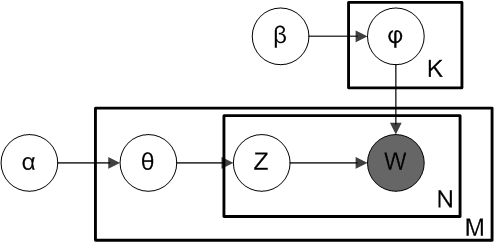

Estimating the parameters could be achieved through Variationnal Bayes EM algorithm.

## Example of LDA in Action

Corpus of Three Documents

1. “cats dogs pets love”
2. “dogs bark loud outside”
3. “politics government election law”

Step 1: Identify Topics

After running LDA, it may discover two topics (dist. over words): - Topic 1 (Pets): {cats, dogs, pets, bark, love} - Topic 2 (Politics): {politics, government, election, law}

Step 2: Assign Topics to Documents

[output not shown]

## Pro and Cons

### Advantages of LDA

- Unsupervised Learning: No labeled data needed.
- Interpretable Topics: Extracts meaningful topics from text.

### Limitations of LDA

- Fixed Number of Topics: Must specify the number of topics beforehand.
- Bag-of-Words Assumption: Ignores word order and context.
- Computationally Expensive: Requires approximation methods for inference.

### Applications of LDA

- Topic Modeling: Organizing large text corpora (news articles, research papers).
- Recommendation Systems: Suggesting articles based on topic similarity.
- Text Classification: Assigning labels based on topic distributions.
- Social Media Analysis: Identifying trending topics in posts.

## Word2vec

### Embeddings

- more powerful word representation
- short dense vectors: $d$ ranging from 50-1000, rather than the much larger vocabulary size $|V|$ or number of documents $D$
- dense vectors work better in every NLP task than sparse vectors

### Skip-gram with negative sampling

- The skip-gram algorithm is one of two algorithms in a software package called word2vec
- The other algorithm is CBOW (continuous bag of words)